# B402A Assignment 7

Lillian Chen, Milan Filipovic, Vivian Truong

5/24/2021

# Allyson Terry’s study on immunologic response to liver allograft injury

## Statement of statistical hypothesis(es):

1. What cytokines are significantly different between IRI- and IRI+ patients in the larger cohort of 100 liver transplant patients?
1. Do these cytokines influence IRI individually?
2. Do these cytokines influence IRI together?
3. Are any of these cytokines significantly different at more than one timepoint?

To determine if cytokines influence IRI individually, binary logistic regression will be conducted with IRI injury as the outcome variable, with difference between timepoints in cytokine concentrations as covariates.

To address what cytokines influence IRI together, a correlation plot was constructed to visualize related cytokines.

To address whether cytokines significantly differ at more than one timepoint, separate one-way anovas with visit type as the factor variable will be conducted with each cytokine as the outcome variable. Furthermore, two-way anovas will be conducted for each cytokine concentration with visit type and IRI status as factor variables to explore if time and IRI status explain variation in cytokine concentration.

2. What cytokines in the pre-transplant blood sample specifically correlate with:
1. Immune cell infiltration after transplant? (Inflammation score)
2. Dead cells in the liver after transplant? (Necrosis score)

To address what cytokines in the pre-transplant blood sample specifically correlate with immune cell infiltration after transplant and dead cells in the liver after transplant, a series of models were conducted using both inflammation score and necrosis score before reaching the best fitted model: ordinal logistic regression model, binary response model, and stepwise regression model.

## Background information:

Ischemia-reperfusion injury (IRI) is when an organ loses and then regains access to blood flow, commonly occurring with organ transplantation. The immune response elicited by IRI can be severe enough to negatively affect the function and survival of the donated organ. One of two main ways that the cells in the body communicate is through cytokines, which are secreted proteins that are present in the blood of transplant patients and can influence the degree of inflammation that occurs during and after IRI. Two characteristics that doctors use to determine if a patient is IRI+ or IRI- are the inflammation score, which is the amount of immune cells in the liver after transplant and the necorsis score, which is the amount of dead cells in the liver after transplant. These characteristics of inflammation and necrosis are scored from 0 to 4, with 0 being the least severe and 4 being the most severe.

## Sample data description:

The study includes 100 liver transplant patients, 42 of which are IRI+ and 58 IRI-. The analysis includes 23 cytokines. The data set also includes the inflammation score, necrosis score, and visit type for each patient.

## Variable assessment:

```
## tibble [300 x 29] (S3: tbl_df/tbl/data.frame)
##  $ Sample #       : num [1:300] 1 2 3 4 5 6 7 8 9 10 ...
##  $ Patient ID     : num [1:300] 4 4 4 5 5 5 6 6 6 7 ...
##  $ IRI Score (–,+): num [1:300] 0 0 0 0 0 0 0 0 0 0 ...
##  $ Inflammation   : num [1:300] 1 1 1 1 1 1 1 1 1 1 ...
##  $ Necrosis       : num [1:300] 0 0 0 0 0 0 0 0 0 0 ...
##  $ Visit Type     : chr [1:300] "PO" "LF" "W1" "PO" ...
##  $ CYTO1          : chr [1:300] "3.62" "8.57" "70.98" "13.75" ...
##  $ CYTO2          : chr [1:300] "18.399999999999999" "361.15" "162.97" "120.96" ...
##  $ CYTO3          : num [1:300] 293 204 206 755 737 ...
##  $ CYTO4          : chr [1:300] "70.069999999999993" "68.459999999999994" "12.56" "2.63" ...
##  $ CYTO5          : chr [1:300] "<0.54↓" "2.76" "3.6" "7.51" ...
##  $ CYTO6          : num [1:300] 101 260 1558 364 1079 ...
##  $ CYTO7          : num [1:300] 22.1 3065 50.1 44.3 240.4 ...
##  $ CYTO8          : chr [1:300] "<2.26↓" "3.21" "<2.26↓" "8.68" ...
##  $ CYTO9          : chr [1:300] "7.41" "5.75" "20.81" "64.84" ...
##  $ CYTO10         : chr [1:300] "1.99" "10.62" "9.67" "8.9700000000000006" ...
##  $ CYTO11         : chr [1:300] "58.41" "187.22" "1478" "149.26" ...
##  $ CYTO12         : chr [1:300] "1.56" "3.06" "1.19" "8.74" ...
##  $ CYTO13         : chr [1:300] "25.57" "1210" "39.07" "127.7" ...
##  $ CYTO14         : chr [1:300] "41.76" "29.2" "97.12" "169.95" ...
##  $ CYTO15         : chr [1:300] "<1.45↓" "1.9" "1.98" "5.51" ...
##  $ CYTO16         : chr [1:300] "<1.09↓" "1.39" "<1.09↓" "<1.09↓" ...
##  $ CYTO17         : chr [1:300] "<1.38↓" "<1.38↓" "<1.38↓" "<1.38↓" ...
##  $ CYTO18         : chr [1:300] "261.95" "107.07" "671.93" "2177" ...
##  $ CYTO19         : chr [1:300] "5.0599999999999996" "3.49" "15.65" "32.85" ...
##  $ CYTO20         : chr [1:300] "71.97" "298.99" "98.69" "203.47" ...
##  $ CYTO21         : chr [1:300] "<2.07↓" "13.49" "6.1" "14.9" ...
##  $ CYTO22         : num [1:300] 37.8 38.1 43.2 103.3 61.1 ...
##  $ CYTO23         : num [1:300] 17.66 18.43 15.37 22.27 2.67 ...
```

```r
library(data.table)
isidata <- fread(file = "dataclean.csv", header = T, stringsAsFactors = F)
(isi_tble <- tibble(isidata))
```

| sample | patientid | IRI | Inflammation | Necrosis | visittype | CYTO1 | CYTO2 | CYTO3 | CYTO4 | CYTO5 | CYTO6 | CYTO7 | CYTO8 | CYTO9 | CYTO10 | CYTO11 | CYTO12 | CYTO13 | CYTO14 | CYTO15 | CYTO16 | CYTO17 | CYTO18 | CYTO19 | CYTO20 | CYTO21 | CYTO22 | CYTO23 |
| --- | --- | --- | --- | --- | --- | --- | --- | --- | --- | --- | --- | --- | --- | --- | --- | --- | --- | --- | --- | --- | --- | --- | --- | --- | --- | --- | --- | --- |
| 1 | 4 | 0 | 1 | 0 | PO | 3.62 | 18.40 | 293.46 | 70.07 | 0.54 | 100.66 | 22.11 | 2.26 | 7.41 | 1.99 | 58.41 | 1.56 | 25.57 | 41.76 | 1.45 | 1.09 | 1.38 | 261.95 | 5.06 | 71.97 | 2.07 | 37.77 | 17.66 |
| 2 | 4 | 0 | 1 | 0 | LF | 8.57 | 361.15 | 203.56 | 68.46 | 2.76 | 259.50 | 3065.00 | 3.21 | 5.75 | 10.62 | 187.22 | 3.06 | 1210.00 | 29.20 | 1.90 | 1.39 | 1.38 | 107.07 | 3.49 | 298.99 | 13.49 | 38.06 | 18.43 |
| 3 | 4 | 0 | 1 | 0 | W1 | 70.98 | 162.97 | 205.70 | 12.56 | 3.60 | 1558.00 | 50.09 | 2.26 | 20.81 | 9.67 | 1478.00 | 1.19 | 39.07 | 97.12 | 1.98 | 1.09 | 1.38 | 671.93 | 15.65 | 98.69 | 6.10 | 43.20 | 15.37 |
| 4 | 5 | 0 | 1 | 0 | PO | 13.75 | 120.96 | 754.99 | 2.63 | 7.51 | 364.36 | 44.30 | 8.68 | 64.84 | 8.97 | 149.26 | 8.74 | 127.70 | 169.95 | 5.51 | 1.09 | 1.38 | 2177.00 | 32.85 | 203.47 | 14.90 | 103.32 | 22.27 |
| 5 | 5 | 0 | 1 | 0 | LF | 3.76 | 515.37 | 737.00 | 0.71 | 1.53 | 1079.00 | 240.41 | 2.26 | 6.35 | 3.29 | 3.86 | 1.19 | 1311.00 | 16.90 | 1.45 | 1.09 | 1.38 | 101.59 | 3.29 | 102.15 | 2.07 | 61.10 | 2.67 |
| 6 | 5 | 0 | 1 | 0 | W1 | 9.72 | 88.38 | 371.99 | 15.52 | 4.88 | 946.77 | 133.55 | 5.25 | 15.40 | 15.20 | 288.79 | 1.74 | 34.90 | 41.76 | 2.07 | 1.09 | 1.38 | 389.59 | 9.51 | 57.60 | 7.64 | 40.58 | 14.24 |
| 7 | 6 | 0 | 1 | 0 | PO | 9.50 | 52.12 | 374.57 | 4.58 | 140.18 | 872.42 | 75.30 | 2.26 | 13.77 | 12.53 | 168.22 | 1.19 | 42.11 | 32.04 | 1.45 | 1.09 | 1.38 | 120.83 | 4.08 | 33.70 | 2.23 | 16.21 | 4.55 |
| 8 | 6 | 0 | 1 | 0 | LF | 12.63 | 153.17 | 119.18 | 11.71 | 102.95 | 566.34 | 323.35 | 2.26 | 14.42 | 12.85 | 234.94 | 1.56 | 1474.00 | 47.52 | 1.60 | 1.09 | 1.38 | 259.20 | 3.88 | 133.89 | 4.52 | 24.71 | 3.75 |
| 9 | 6 | 0 | 1 | 0 | W1 | 2.98 | 34.29 | 391.12 | 17.62 | 22.95 | 457.26 | 215.15 | 2.26 | 2.96 | 8.74 | 44.22 | 2.11 | 77.02 | 9.62 | 1.45 | 1.09 | 1.38 | 11.90 | 0.89 | 15.91 | 2.07 | 43.98 | 20.43 |
| 10 | 7 | 0 | 1 | 0 | PO | 8.92 | 85.63 | 151.23 | 33.72 | 4.45 | 260.65 | 32.87 | 4.55 | 32.78 | 7.36 | 146.35 | 3.25 | 82.27 | 111.80 | 3.00 | 1.09 | 1.38 | 1254.00 | 48.33 | 207.03 | 3.01 | 75.22 | 8.35 |

[output cut: 290 more lines]

Create patient characteristics table.

```r
#namess
library(gtsummary)

CYTO <- names(isi_tble[7:29])  #vector of cytokine variable names

demographic_table <- isi_tble %>%
   mutate(IRI = ifelse( IRI == 0, "IRI-", "IRI+")) %>%
  select(-patientid, -sample) %>%
  tbl_summary(by = IRI,
              statistic = CYTO ~
              "{median} ({p25}, {p75})",
              digits = all_continuous() ~ 2,
              label = list(visittype ~ "Visit Type"),
              missing_text = "Missing") %>%
  add_overall() %>%
  bold_labels() %>%
  add_p() %>%
  bold_p() %>%
  modify_header(label ~ "**Table 1. Patient Characteristics**" )
demographic_table
```

| **Table 1. Patient Characteristics** | **Overall**, N = 300<sup>1</sup> | **IRI-**, N = 174<sup>1</sup> | **IRI+**, N = 126<sup>1</sup> | **p-value**<sup>2</sup> |
| --- | --- | --- | --- | --- |
| Inflammation |  |  |  | <0.001 |
| 0 | 27 (9.0%) | 24 (14%) | 3 (2.4%) |  |
| 1 | 177 (59%) | 126 (72%) | 51 (40%) |  |
| 2 | 78 (26%) | 21 (12%) | 57 (45%) |  |
| 3 | 18 (6.0%) | 3 (1.7%) | 15 (12%) |  |
| Necrosis |  |  |  | <0.001 |
| 0 | 75 (25%) | 72 (41%) | 3 (2.4%) |  |
| 1 | 111 (37%) | 99 (57%) | 12 (9.5%) |  |
| 2 | 72 (24%) | 3 (1.7%) | 69 (55%) |  |
| 3 | 36 (12%) | 0 (0%) | 36 (29%) |  |
| 4 | 6 (2.0%) | 0 (0%) | 6 (4.8%) |  |
| Visit Type |  |  |  | >0.9 |
| LF | 100 (33%) | 58 (33%) | 42 (33%) |  |
| PO | 100 (33%) | 58 (33%) | 42 (33%) |  |
| W1 | 100 (33%) | 58 (33%) | 42 (33%) |  |
| CYTO1 | 8.70 (4.30, 15.69) | 8.94 (4.04, 15.62) | 8.62 (4.83, 15.55) | 0.6 |
| CYTO2 | 128.04 (66.54, 359.61) | 122.28 (66.32, 360.64) | 129.10 (69.68, 352.29) | 0.9 |
| CYTO3 | 229.10 (151.17, 324.17) | 232.78 (151.52, 326.69) | 221.18 (149.24, 312.09) | 0.7 |
| CYTO4 | 24.62 (11.54, 45.87) | 23.44 (13.08, 43.24) | 25.07 (9.51, 47.88) | 0.9 |
| CYTO5 | 3.79 (1.53, 8.85) | 3.79 (1.76, 8.32) | 3.80 (1.33, 9.34) | 0.8 |
| CYTO6 | 271.99 (152.17, 459.83) | 277.15 (172.53, 509.27) | 262.06 (140.55, 397.65) | 0.2 |
| CYTO7 | 88.35 (44.57, 243.92) | 94.28 (44.34, 276.30) | 84.80 (46.80, 198.98) | 0.7 |
| CYTO8 | 3.33 (2.01, 7.73) | 3.36 (2.00, 7.79) | 3.29 (2.10, 7.70) | 0.8 |
| CYTO9 | 15.16 (5.07, 46.98) | 15.32 (4.51, 48.28) | 14.98 (6.52, 42.99) | 0.8 |
| CYTO10 | 10.12 (6.03, 15.21) | 9.62 (5.75, 14.88) | 10.27 (6.60, 16.62) | 0.3 |
| CYTO11 | 92.06 (44.36, 178.51) | 101.12 (46.94, 189.43) | 68.12 (37.17, 158.68) | 0.037 |
| CYTO12 | 2.86 (1.58, 6.04) | 2.66 (1.58, 6.16) | 2.99 (1.56, 5.90) | 0.5 |
| CYTO13 | 149.50 (69.78, 1,568.25) | 145.42 (59.26, 1,468.50) | 168.98 (82.33, 2,155.00) | 0.3 |
| CYTO14 | 66.06 (20.62, 189.05) | 63.72 (17.14, 197.00) | 71.24 (26.99, 179.49) | 0.5 |
| CYTO15 | 3.16 (1.51, 7.11) | 3.00 (1.48, 7.26) | 3.27 (1.67, 6.22) | 0.8 |
| CYTO16 | 1.10 (0.94, 1.60) | 1.10 (0.81, 1.55) | 1.10 (0.94, 1.92) | 0.064 |
| CYTO17 | 1.38 (1.33, 1.41) | 1.39 (1.33, 1.41) | 1.34 (1.06, 1.41) | 0.018 |
| CYTO18 | 431.17 (131.20, 1,351.75) | 388.58 (109.13, 1,363.25) | 491.25 (189.98, 1,316.75) | 0.3 |
| CYTO19 | 8.79 (3.79, 24.11) | 7.98 (3.34, 25.27) | 10.02 (4.52, 21.50) | 0.5 |
| CYTO20 | 152.46 (68.05, 306.70) | 137.80 (61.75, 298.48) | 163.06 (70.80, 336.67) | 0.3 |
| CYTO21 | 5.24 (2.79, 12.36) | 5.24 (2.59, 13.66) | 5.26 (3.28, 11.09) | 0.8 |
| CYTO22 | 58.27 (35.16, 107.86) | 49.77 (31.09, 92.57) | 75.42 (37.61, 117.85) | 0.005 |
| CYTO23 | 20.20 (13.20, 30.07) | 18.40 (12.97, 28.57) | 21.86 (13.45, 32.78) | 0.065 |

<sup>*1*</sup> n (%); Median (IQR) <sup>*2*</sup> Pearson's Chi-squared test; Fisher's exact test; Wilcoxon rank sum test

It should be noted that a significant difference between IRI- and IRI+ patients was detected for necrosis score (p <.001).

The significance test for cytokine concentration was conducted using a nonparametric method, so it is more robust to assumptions of normality. CYTO11, CYTO17, and CYTO22 were found to be significantly different. Next we visualize the distribution of cytokine concentration.

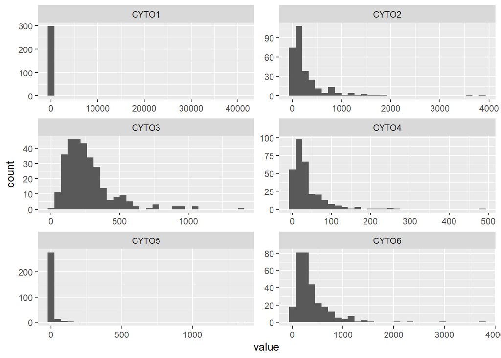

```r
isi_tble %>%
  select(CYTO1:CYTO6) %>%
  gather() %>%
  ggplot(aes(value)) +
 facet_wrap(~ key, nrow = 3, scales = "free") +
  geom_histogram()
```

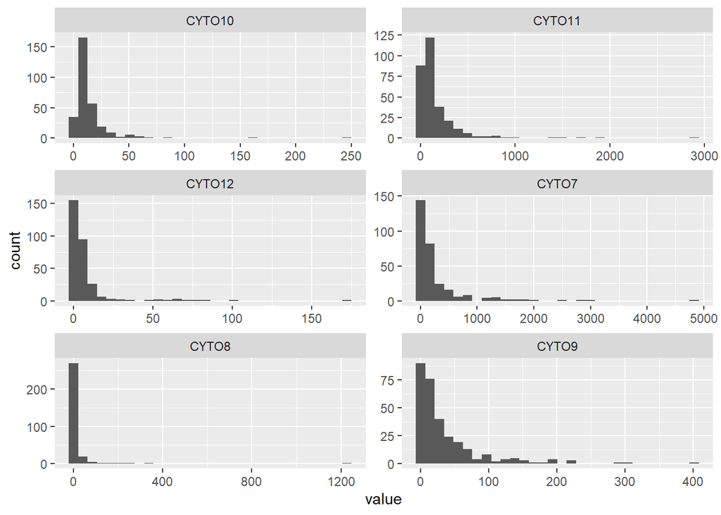

```r
isi_tble %>%
  select(CYTO7:CYTO12) %>%
  gather() %>%
  ggplot(aes(value)) +
 facet_wrap(~ key, nrow = 3, scales = "free") +
  geom_histogram()
```

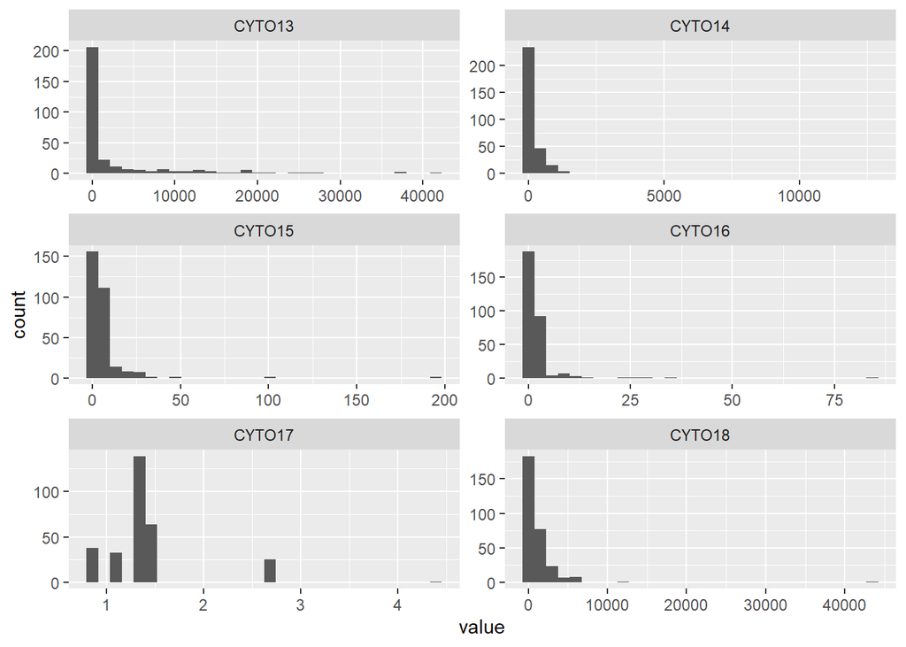

```r
isi_tble %>%
  select(CYTO13:CYTO18) %>%
  gather() %>%
  ggplot(aes(value)) +
 facet_wrap(~ key, nrow = 3, scales = "free") +
  geom_histogram()
```

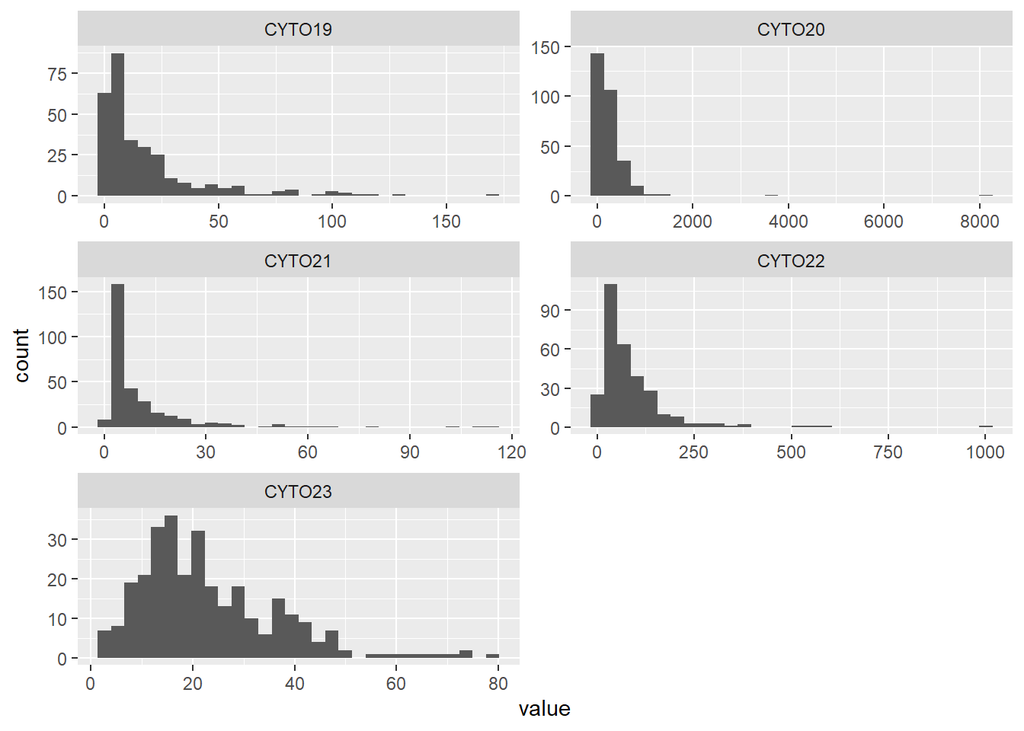

```r
isi_tble %>%
  select(CYTO19:CYTO23) %>%
  gather() %>%
  ggplot(aes(value)) +
 facet_wrap(~ key, nrow = 3, scales = "free") +
  geom_histogram()
```

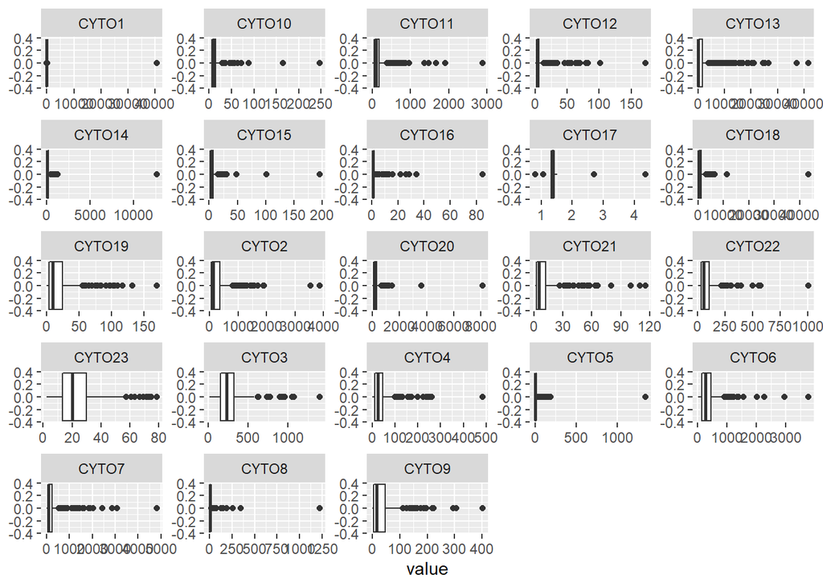

```r
## my attempt to facet in one plot. Does not look good
isi_tble %>% select(starts_with("CYT")) %>%
  gather() %>%
  ggplot(aes(value)) +
facet_wrap(~ key, scales ="free") +
# facet_grid_paginate(~ key, ncol = 3, nrow = 3, page = 2)
  geom_boxplot()
```

The Cytokine distributions are characterized by heavy right skew.

Now log transform all Cytokines

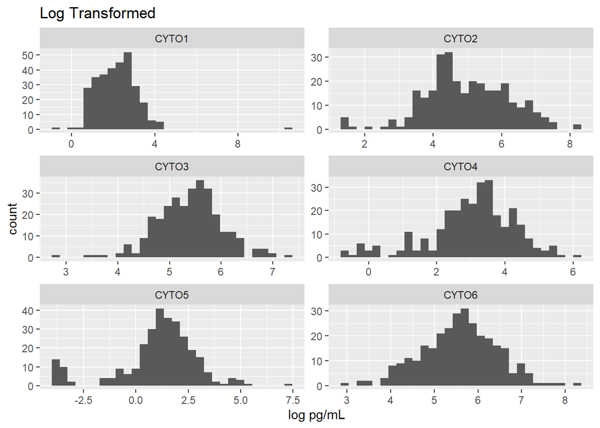

```r
isi_tble %>%
  select(CYTO1:CYTO6) %>%
  gather() %>%
  ggplot(aes(log(value))) +
 facet_wrap(~ key, nrow = 3, scales = "free") +
  geom_histogram() +
  labs(title = "Log Transformed") +
  xlab("log pg/mL")
```

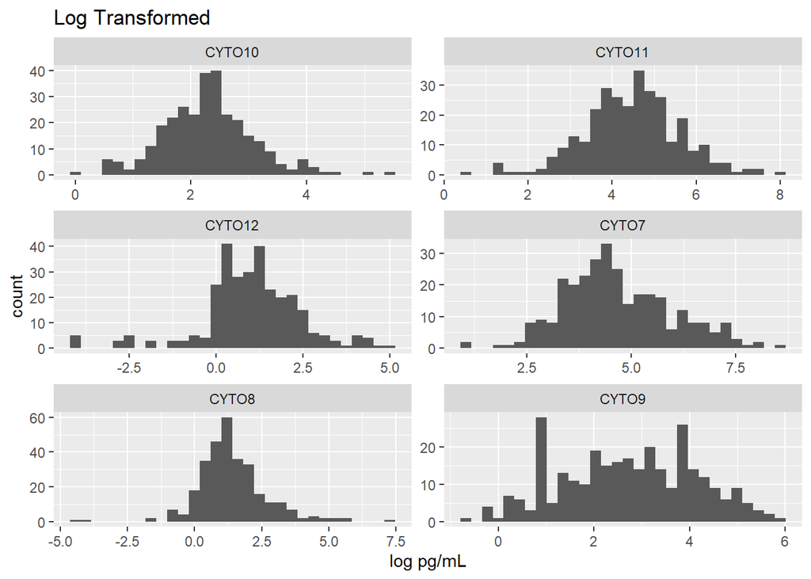

```r
isi_tble %>%
  select(CYTO7:CYTO12) %>%
  gather() %>%
  ggplot(aes(log(value))) +
 facet_wrap(~ key, nrow = 3, scales = "free") +
  geom_histogram() +
  labs(title = "Log Transformed") +
  xlab("log pg/mL")
```

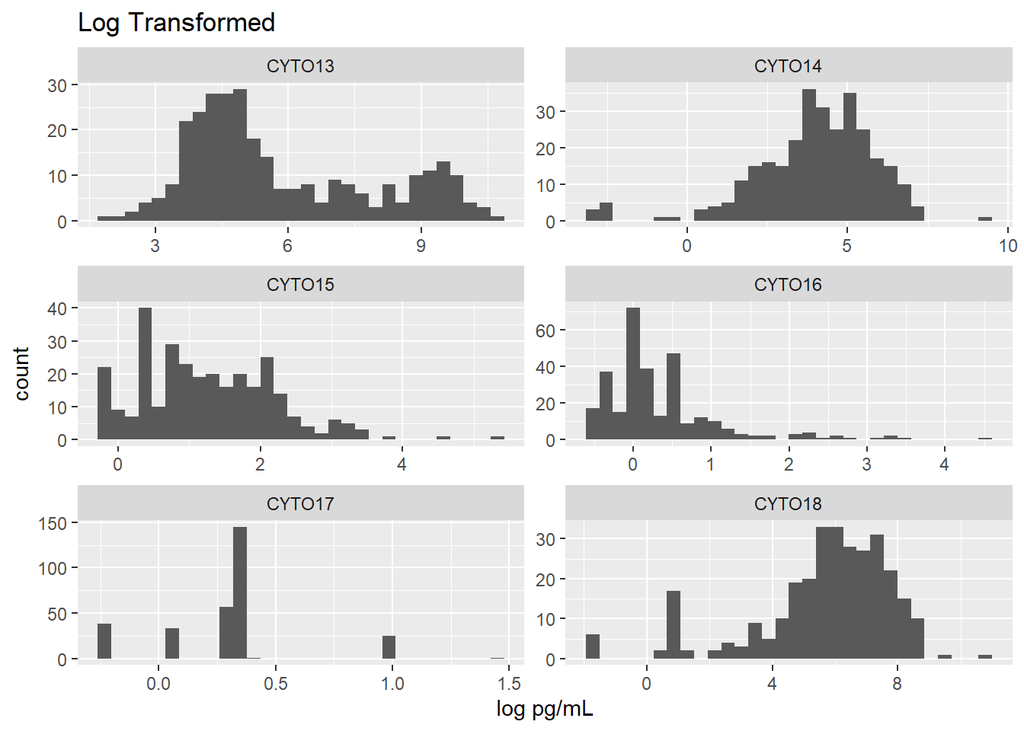

```r
isi_tble %>%
  select(CYTO13:CYTO18) %>%
  gather() %>%
  ggplot(aes(log(value))) +
 facet_wrap(~ key, nrow = 3, scales = "free") +
  geom_histogram() +
  labs(title = "Log Transformed") +
  xlab("log pg/mL")
```

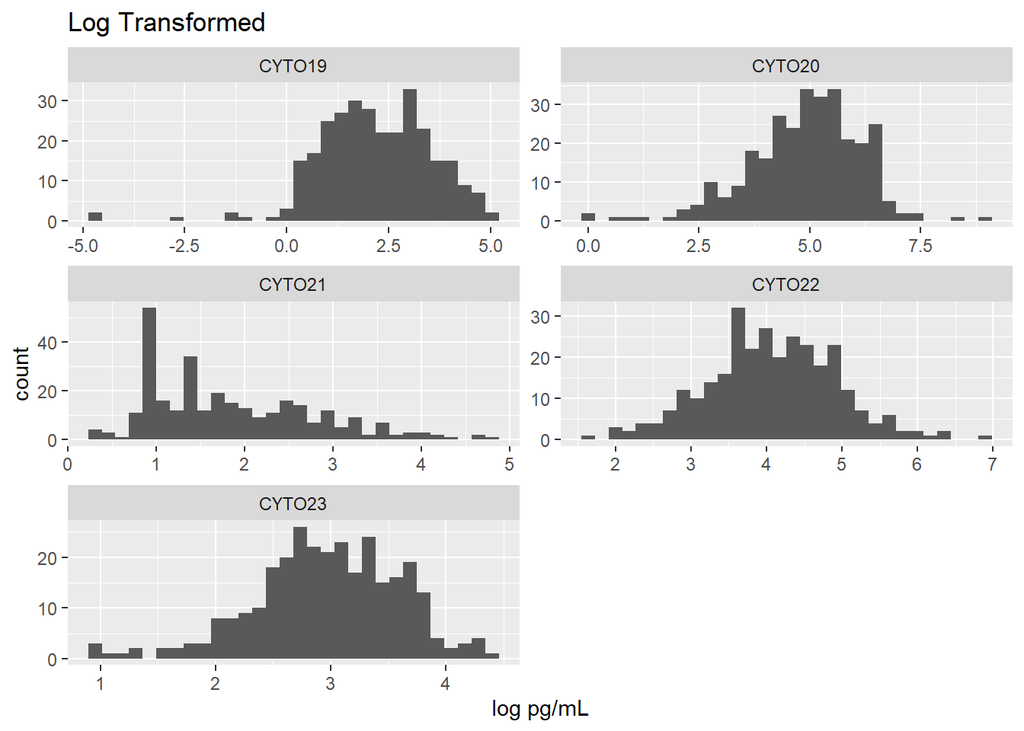

```r
isi_tble %>%
  select(CYTO19:CYTO23) %>%
  gather() %>%
  ggplot(aes(log(value))) +
 facet_wrap(~ key, nrow = 3, scales = "free") +
  geom_histogram() +
  labs(title = "Log Transformed") +
  xlab("log pg/mL")
```

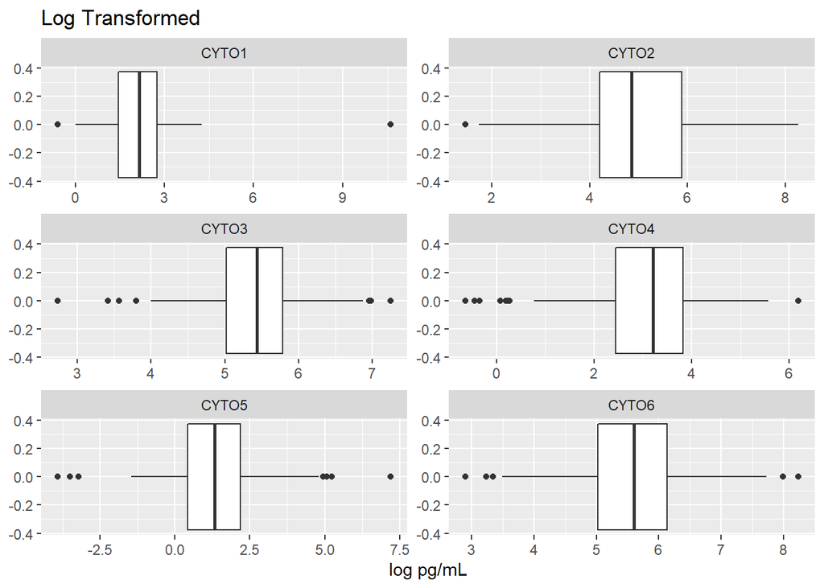

```r
isi_tble %>%
  select(CYTO1:CYTO6) %>%
  gather() %>%
  ggplot(aes(log(value))) +
 facet_wrap(~ key, nrow = 3, scales = "free") +
  geom_boxplot() +
  labs(title = "Log Transformed") +
  xlab("log pg/mL")
```

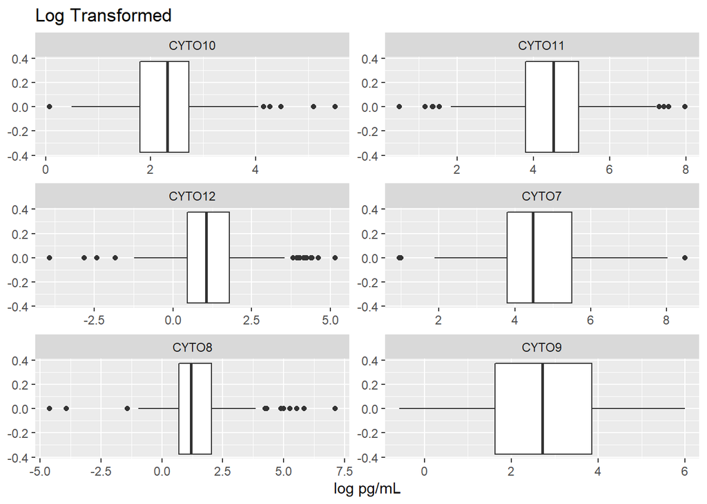

```r
isi_tble %>%
  select(CYTO7:CYTO12) %>%
  gather() %>%
  ggplot(aes(log(value))) +
 facet_wrap(~ key, nrow = 3, scales = "free") +
  geom_boxplot() +
  labs(title = "Log Transformed") +
  xlab("log pg/mL")
```

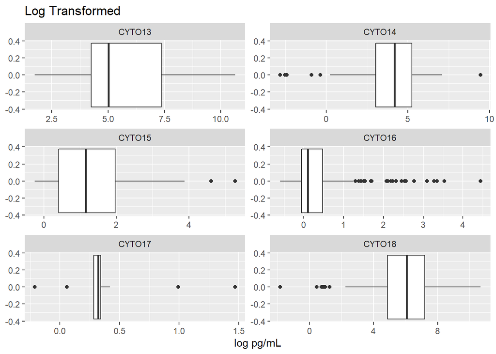

```r
isi_tble %>%
  select(CYTO13:CYTO18) %>%
  gather() %>%
  ggplot(aes(log(value))) +
 facet_wrap(~ key, nrow = 3, scales = "free") +
  geom_boxplot() +
  labs(title = "Log Transformed") +
  xlab("log pg/mL")
```

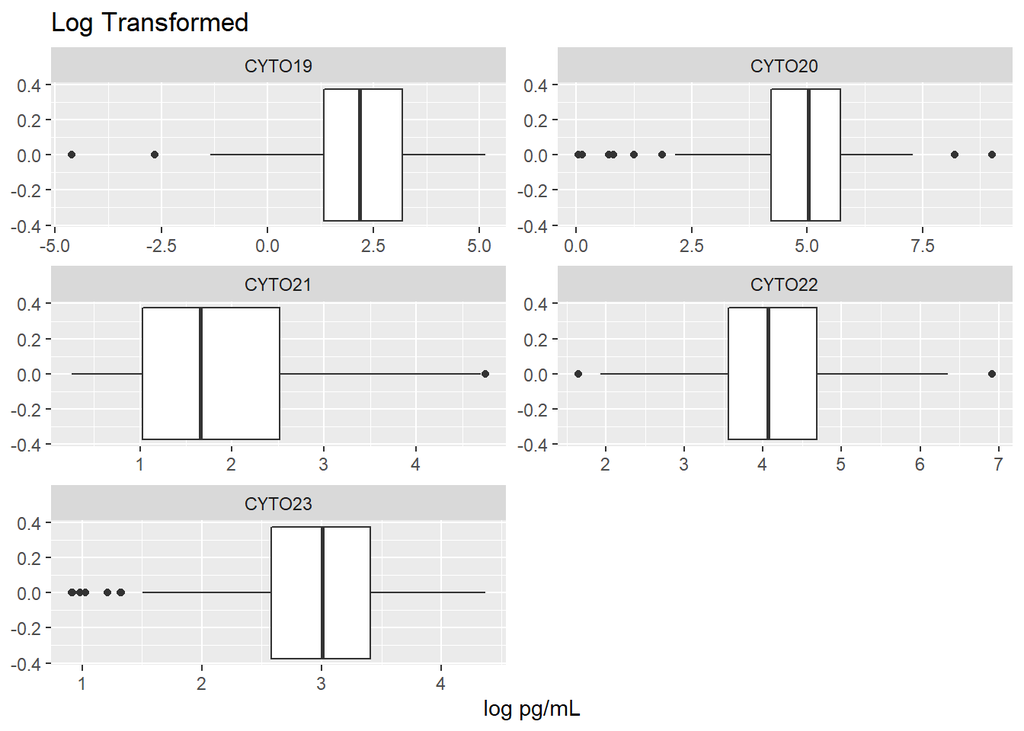

```r
isi_tble %>%
  select(CYTO19:CYTO23) %>%
  gather() %>%
  ggplot(aes(log(value))) +
 facet_wrap(~ key, nrow = 3, scales = "free") +
  geom_boxplot() +
  labs(title = "Log Transformed") +
  xlab("log pg/mL")
```

- Among the log transformed cytokine values, it is seen that that overall normality is improved.
- CYTO12 and CYTO 19 appears to have a similar distribution when looking at the histogram, with large left skew and lack of density left of the peak density.
- CYTO13 appears as if it may have another peak in the right tail. It is right skewed.
- CYTO 15 appears to have several outliers in the higher range.
- CYTO16 appears right skewed.
- CYTO18 appears to have lower outliers.
- CYTO17 has many values below level of detection, therefore the transformation did not affect overall normality.
- CYTO21 appears to have a large right skew, though it should be noted that many values were below level of detection in CYTO 21.

It should be noted that due to many observations below detection, CytO17 should not be included in the linear models that follow.

### Cytokines Trending With Time by Anova

First look at how cytokine values trend overtime

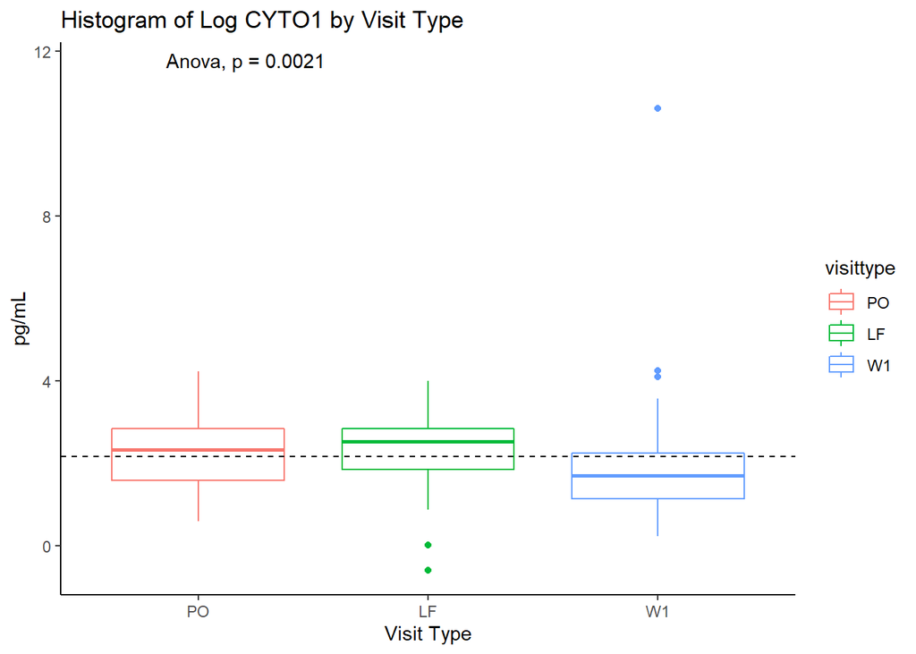

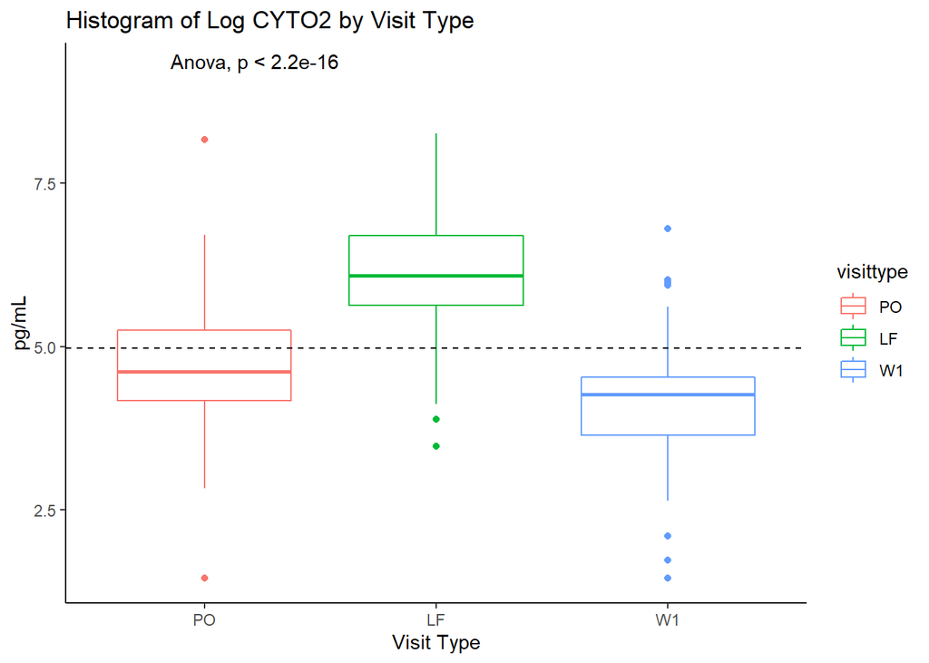

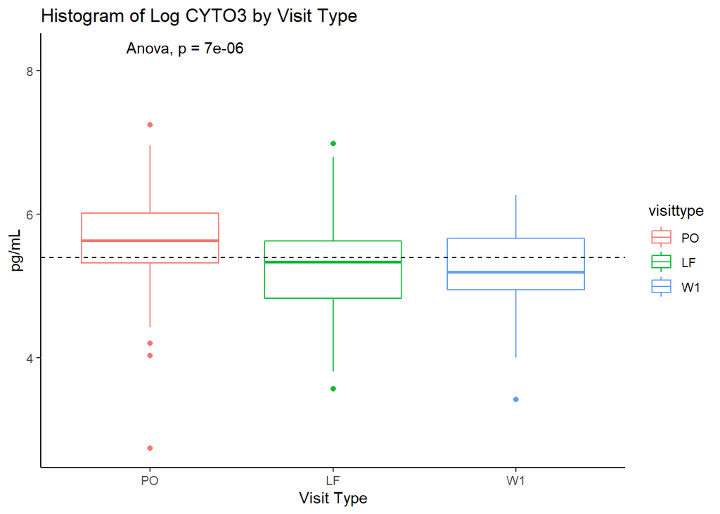

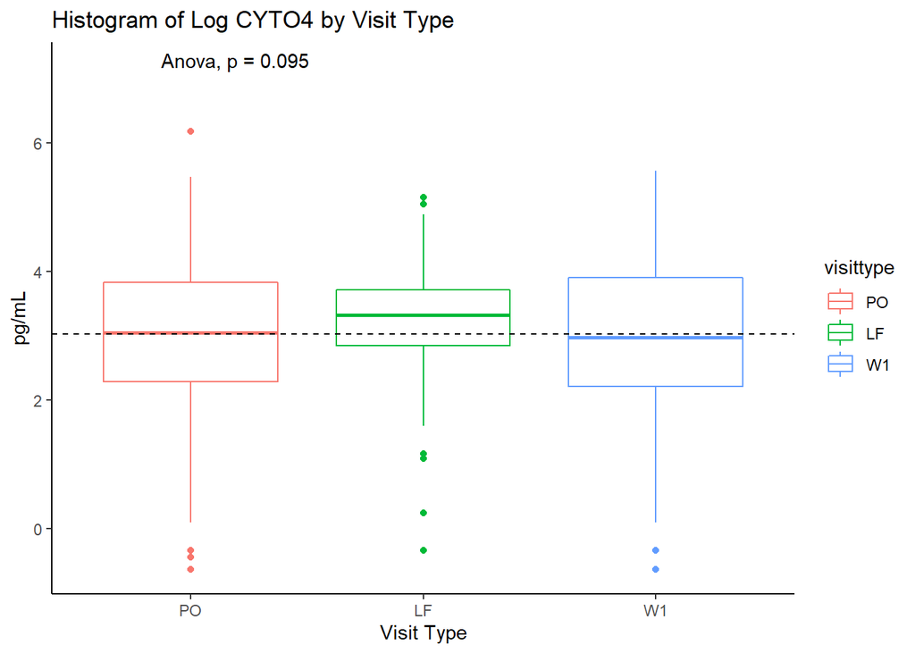

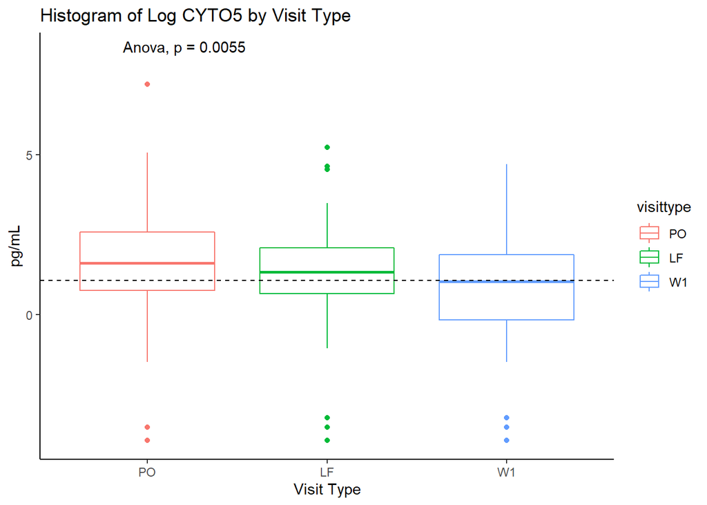

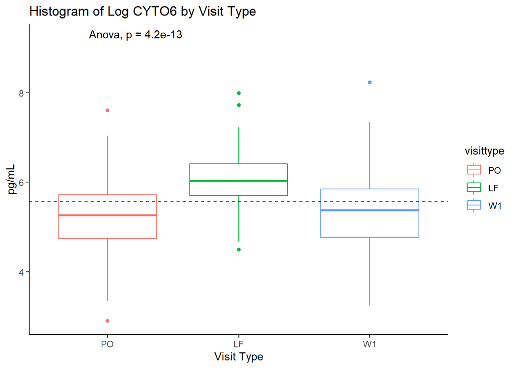

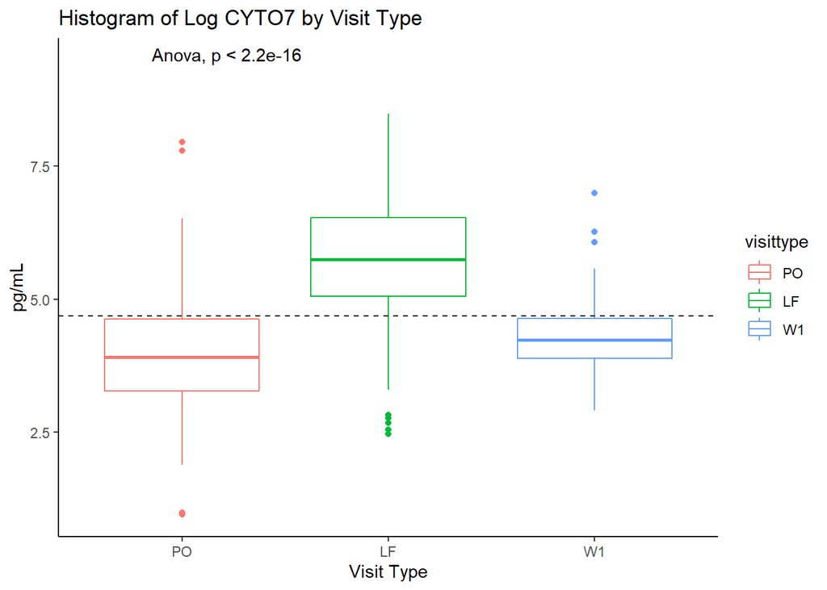

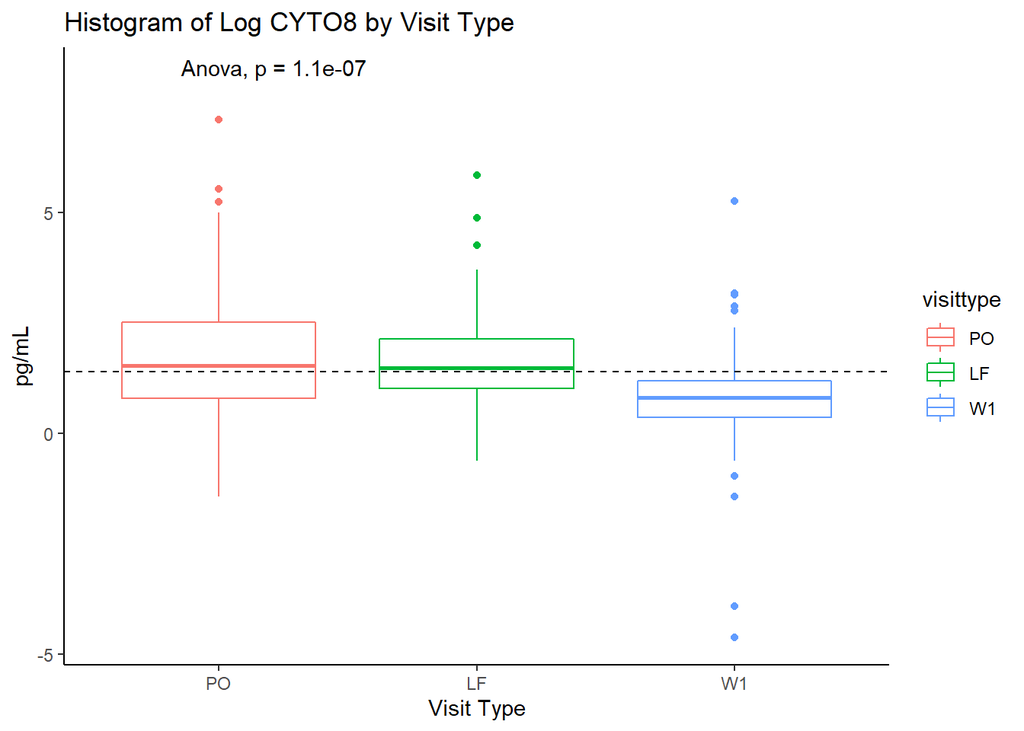

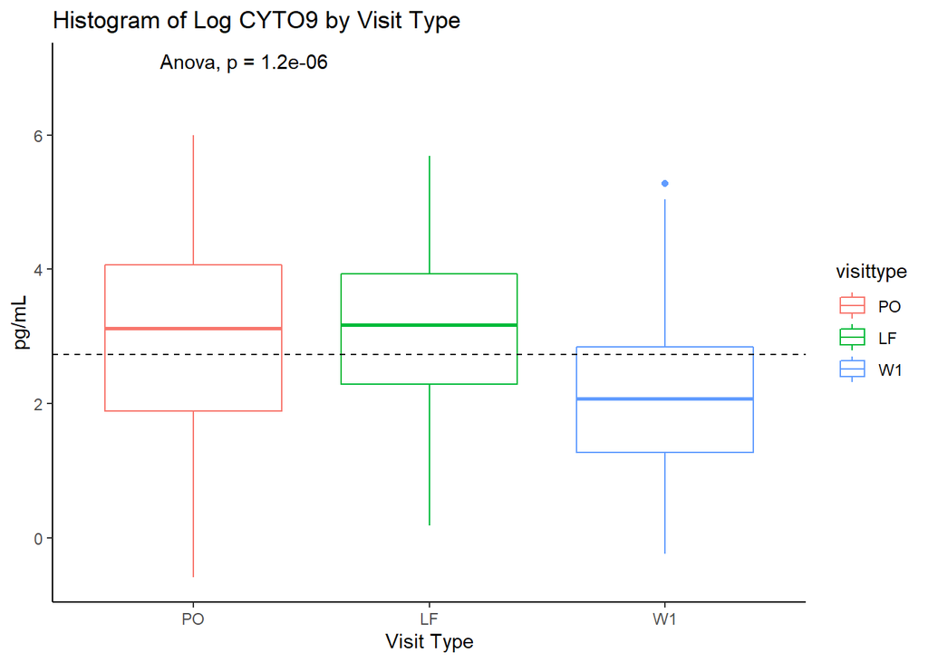

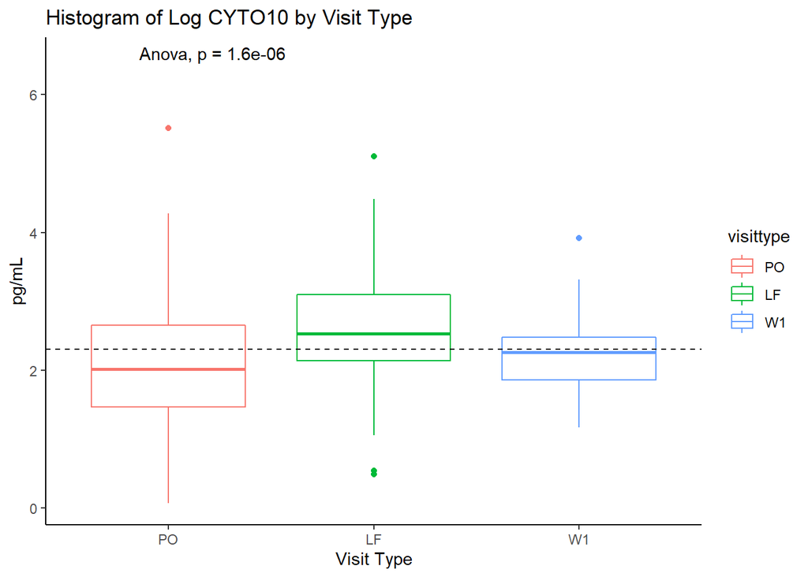

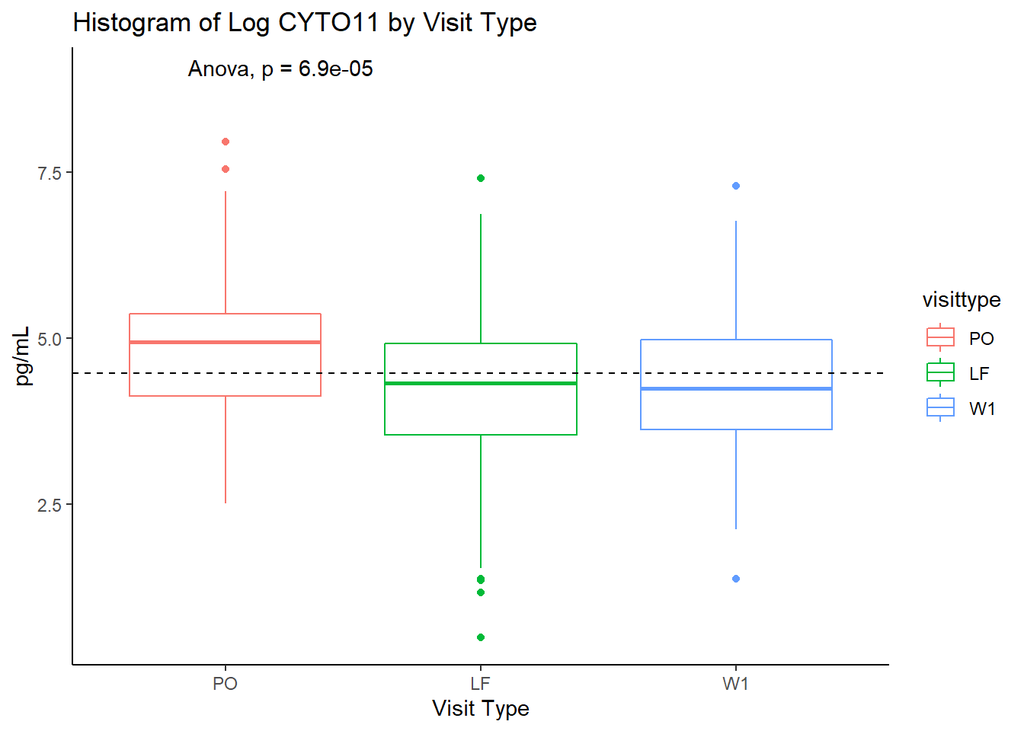

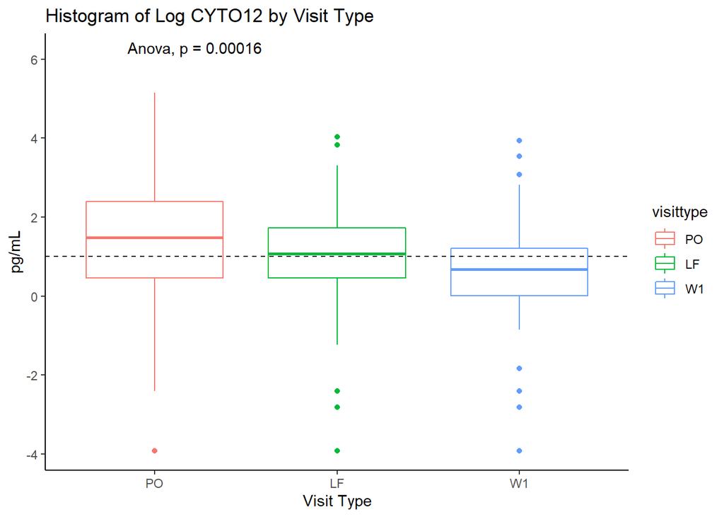

[11 more figures not shown]

```r
library(ggpubr)


#Reordering the visittype
isi_tble$visittype <- factor(isi_tble$visittype, levels = c("PO", "LF", "W1"))

#One-way anova at each timepoint
for(i in c(7:29)){
p <- isi_tble %>%
  ggplot() +
  geom_boxplot(aes(x = visittype, y = log(isi_tble[[i]]), color = visittype)) +
  stat_compare_means(aes( x = visittype, y = log(isi_tble[[i]])), method = "anova",
                     label.y = (max(log(isi_tble[[i]])) + 1)) + #positions the anova stat
  # stat_compare_means(aes( x = visittype, y = log(isi_tble[[i]])), label = "p.signif", method = "t.test",
  #                    ref.group = ".all.") +
  geom_hline(yintercept = mean(log(isi_tble[[i]])), linetype = 2) + #adds horizontal line for mean
  ggtitle(paste("Histogram of Log", names(isi_tble)[i], "by Visit Type")) +
  ylab("pg/mL") +
  xlab("Visit Type") +
  theme_classic()
print(p)
}
```

### Histogram By Visit Type Interpretation

Only CYTO4, CYTO16, and CYTO17 concentrations are not significantly different at the different visits by one way anova. In all other cytokines, an overall difference in mean concentration was detected. The overall mean at all timepoints is displayed with a horizontal line.

In many of the cytokines, the concentration at the LF timepoint is larger, suggesting an elevated immune response during the LF timepoint. These cytokines include CYTO2, CYTO6, CYTO 7, CYTO13, CYTO20. The concentration of CYTO22 appears to decrease at each timepoint.

To investigate this further, pairwise comparisons will be conducted using Tukey’s HSD.

```r
# Log Transforming Data to use in anova modelling.

liri_tble <- isi_tble %>% select(starts_with("CYT")) %>%
  log() %>% #log transforms the cytokine data frame
  mutate(visittype = isi_tble$visittype, IRI = isi_tble$IRI, ID = isi_tble$patientid) #add the factor variables back in
responseList <- names(liri_tble)[c(1:23)]

modelList    <- lapply(responseList, function(resp) {
                           mF <- formula(paste(resp, " ~ visittype"))
                           aov(mF, data = liri_tble)
                })

HSDList    <- lapply(modelList, function(mod) {
                           TukeyHSD(mod)
                })
HSDList
```

```
## [[1]]
##   Tukey multiple comparisons of means
##     95% family-wise confidence level
##
## Fit: aov(formula = mF, data = liri_tble)
##
## $visittype
##              diff        lwr         upr     p adj
## LF-PO  0.06840745 -0.2558110  0.39262592 0.8728010
## W1-PO -0.38474438 -0.7089628 -0.06052591 0.0152141
## W1-LF -0.45315183 -0.7773703 -0.12893337 0.0031873
##
##
## [[2]]
##   Tukey multiple comparisons of means
##     95% family-wise confidence level
##
## Fit: aov(formula = mF, data = liri_tble)
##
## $visittype
##             diff        lwr        upr    p adj
## LF-PO  1.4051474  1.1024736  1.7078211 0.00e+00
## W1-PO -0.5458561 -0.8485298 -0.2431823 8.55e-05
## W1-LF -1.9510034 -2.2536772 -1.6483296 0.00e+00
##
##
## [[3]]
##   Tukey multiple comparisons of means
##     95% family-wise confidence level
##
## Fit: aov(formula = mF, data = liri_tble)
##
## $visittype
##              diff        lwr        upr     p adj
## LF-PO -0.34268195 -0.5428843 -0.1424796 0.0002074
## W1-PO -0.38544874 -0.5856511 -0.1852464 0.0000249
## W1-LF -0.04276679 -0.2429691  0.1574355 0.8698349
##
##
## [[4]]
```

[output cut: 242 more lines]

```
## W1-PO -0.6548417 -0.9260086 -0.3836748 0.0000001
## W1-LF -0.5533990 -0.8245658 -0.2822321 0.0000073
##
##
## [[23]]
##   Tukey multiple comparisons of means
##     95% family-wise confidence level
##
## Fit: aov(formula = mF, data = liri_tble)
##
## $visittype
##             diff         lwr        upr     p adj
## LF-PO -0.6466722 -0.82377924 -0.4695653 0.0000000
## W1-PO  0.1462652 -0.03084183  0.3233722 0.1279238
## W1-LF  0.7929374  0.61583041  0.9700444 0.0000000
```

CYTO 2, CYTO13 and CYTO20 were significantly different for each pairwise comparison.

### Interaction Plots

To explore how cytokine concentrations trend over time in IRI positive and negative patients, interaction plots between IRI status and visit are visualized below. Here median values are plotted over the visit types. It should be noted that CYTO4, CYTO16, and CYTO17 were not included because significance was not found in the anova test.